# Capstone_updated

## **Lets import all the necessary libraries**

```python
from google.colab import drive
drive.mount('/content/drive')
```

```python
import keras
import numpy as np
import matplotlib.pyplot as plt
import os, shutil, random, cv2
import glob, pylab, pandas as pd
from keras.models import Model
import  keras.optimizers as optimizers
from keras.preprocessing.image import ImageDataGenerator
from keras.layers import Input, Dense, Dropout,Flatten, AveragePooling2D, GlobalAveragePooling2D, Concatenate

from keras.layers.normalization import BatchNormalization
from keras.layers.convolutional import Convolution2D, MaxPooling2D
from keras.utils import plot_model

from sklearn.metrics import classification_report
from sklearn.metrics import confusion_matrix
import matplotlib.patches as patches
keras.__version__
```

```
'2.3.1'
```

# **Download dataset from kaggle**

```python
from google.colab import files
files.upload()
```

Upload widget is only available when the cell has been executed in the current browser session. Please rerun this cell to enable.

```
{}
```

```python
! mkdir ~/.kaggle
! cp kaggle.json ~/.kaggle/
! chmod 600 ~/.kaggle/kaggle.json
```

```python
!pip uninstall -y kaggle
!pip install --upgrade pip
!pip install kaggle==1.5.6
!kaggle -v
```

```
Uninstalling kaggle-1.5.6:
  Successfully uninstalled kaggle-1.5.6
     |████████████████████████████████| 1.5MB 8.9MB/s
  Found existing installation: pip 19.3.1
    Uninstalling pip-19.3.1:
      Successfully uninstalled pip-19.3.1
     |████████████████████████████████| 58 kB 4.0 MB/s
Kaggle API 1.5.6
```

```python
#lets download dataset
!kaggle competitions download -c rsna-pneumonia-detection-challenge
```

```
Downloading rsna-pneumonia-detection-challenge.zip to /content
100% 3.66G/3.66G [01:09<00:00, 44.0MB/s]
100% 3.66G/3.66G [01:09<00:00, 56.8MB/s]
```

```python
#lets unzip dataset
!unzip rsna-pneumonia-detection-challenge.zip
```

[output not shown]

[output cut: 4945 more lines]

[output not shown]

```python
!ls #check the files and folders in current directory
```

```
 drive					  stage_2_detailed_class_info.csv
'GCP Credits Request Link - RSNA.txt'	  stage_2_sample_submission.csv
 kaggle.json				  stage_2_test_images
 rsna-pneumonia-detection-challenge.zip   stage_2_train_images
 sample_data				  stage_2_train_labels.csv
```

# Lets see the files that we have

**stage_2_train_image**s: Directory containing training set raw image (DICOM) files

**stage_2_test_images**: Directory containing test set raw image (DICOM) files

**stage_2_detailed_class_info**.csv: Contains detailed information about the positive and negative classes in the training set

**stage_2_train_labels.csv**: CSV file containing training set patientIds and labels (including bounding boxes)

The training data is provided as a set of patientIds and bounding boxes. Bounding boxes are defined as follows: x-min y-min width height

There is also a binary target column, Target, indicating pneumonia or non-pneumonia.

There may be multiple rows per patientId.

```python
train_labels = pd.read_csv('stage_2_train_labels.csv')
data_info = pd.read_csv('stage_2_detailed_class_info.csv')
sample_submission = pd.read_csv('stage_2_sample_submission.csv')
```

```python
sample_submission.head()
```

|  | patientId | PredictionString |
| --- | --- | --- |
| 0 | 0000a175-0e68-4ca4-b1af-167204a7e0bc | 0.5 0 0 100 100 |
| 1 | 0005d3cc-3c3f-40b9-93c3-46231c3eb813 | 0.5 0 0 100 100 |
| 2 | 000686d7-f4fc-448d-97a0-44fa9c5d3aa6 | 0.5 0 0 100 100 |
| 3 | 000e3a7d-c0ca-4349-bb26-5af2d8993c3d | 0.5 0 0 100 100 |
| 4 | 00100a24-854d-423d-a092-edcf6179e061 | 0.5 0 0 100 100 |

```python
data_info.head()
```

|  | patientId | class |
| --- | --- | --- |
| 0 | 0004cfab-14fd-4e49-80ba-63a80b6bddd6 | No Lung Opacity / Not Normal |
| 1 | 00313ee0-9eaa-42f4-b0ab-c148ed3241cd | No Lung Opacity / Not Normal |
| 2 | 00322d4d-1c29-4943-afc9-b6754be640eb | No Lung Opacity / Not Normal |
| 3 | 003d8fa0-6bf1-40ed-b54c-ac657f8495c5 | Normal |
| 4 | 00436515-870c-4b36-a041-de91049b9ab4 | Lung Opacity |

```python
train_labels.head()
```

|  | patientId | x | y | width | height | Target |
| --- | --- | --- | --- | --- | --- | --- |
| 0 | 0004cfab-14fd-4e49-80ba-63a80b6bddd6 | NaN | NaN | NaN | NaN | 0 |
| 1 | 00313ee0-9eaa-42f4-b0ab-c148ed3241cd | NaN | NaN | NaN | NaN | 0 |
| 2 | 00322d4d-1c29-4943-afc9-b6754be640eb | NaN | NaN | NaN | NaN | 0 |
| 3 | 003d8fa0-6bf1-40ed-b54c-ac657f8495c5 | NaN | NaN | NaN | NaN | 0 |
| 4 | 00436515-870c-4b36-a041-de91049b9ab4 | 264.0 | 152.0 | 213.0 | 379.0 | 1 |

```python
train_labels.info()
```

```
<class 'pandas.core.frame.DataFrame'>
RangeIndex: 30227 entries, 0 to 30226
Data columns (total 6 columns):
 #   Column     Non-Null Count  Dtype
---  ------     --------------  -----
 0   patientId  30227 non-null  object
 1   x          9555 non-null   float64
 2   y          9555 non-null   float64
 3   width      9555 non-null   float64
 4   height     9555 non-null   float64
 5   Target     30227 non-null  int64
dtypes: float64(4), int64(1), object(1)
memory usage: 1.4+ MB
```

```python
sample = train_labels.iloc[0,:]
sample2 = train_labels.iloc[15,:]
```

```python
sample
```

```
patientId    0004cfab-14fd-4e49-80ba-63a80b6bddd6
x                                             NaN
y                                             NaN
width                                         NaN
height                                        NaN
Target                                          0
Name: 0, dtype: object
```

```python
sample2
```

```
patientId    00aecb01-a116-45a2-956c-08d2fa55433f
x                                             547
y                                             299
width                                         119
height                                        165
Target                                          1
Name: 15, dtype: object
```

As you can see the training data information consists of:

patiendId One unique value for each patient

Target Either 0 or 1 for absence or presence of pneumonia, respectively

width and height The width and the height of the bounding box, if the Target is 0 the value of the width and the height will be NaN

# **Images**

Images are in DICOM format. To handle with this format we are going to use Pydicom

```python
!pip install pydicom #install pdicom for dicom images
```

```
     |████████████████████████████████| 35.3 MB 32 kB/s
```

```python
import pydicom #will improt pydicom
```

```python
patientId = train_labels['patientId'][0]
dcm_file = 'stage_2_train_images/%s.dcm' % patientId
dcm_data = pydicom.read_file(dcm_file)

print(dcm_data)
```

```
(0008, 0005) Specific Character Set              CS: 'ISO_IR 100'
(0008, 0016) SOP Class UID                       UI: Secondary Capture Image Storage
(0008, 0018) SOP Instance UID                    UI: 1.2.276.0.7230010.3.1.4.8323329.28530.1517874485.775526
(0008, 0020) Study Date                          DA: '19010101'
(0008, 0030) Study Time                          TM: '000000.00'
(0008, 0050) Accession Number                    SH: ''
(0008, 0060) Modality                            CS: 'CR'
(0008, 0064) Conversion Type                     CS: 'WSD'
(0008, 0090) Referring Physician's Name          PN: ''
(0008, 103e) Series Description                  LO: 'view: PA'
(0010, 0010) Patient's Name                      PN: '0004cfab-14fd-4e49-80ba-63a80b6bddd6'
(0010, 0020) Patient ID                          LO: '0004cfab-14fd-4e49-80ba-63a80b6bddd6'
(0010, 0030) Patient's Birth Date                DA: ''
(0010, 0040) Patient's Sex                       CS: 'F'
(0010, 1010) Patient's Age                       AS: '51'
(0018, 0015) Body Part Examined                  CS: 'CHEST'
(0018, 5101) View Position                       CS: 'PA'
(0020, 000d) Study Instance UID                  UI: 1.2.276.0.7230010.3.1.2.8323329.28530.1517874485.775525
(0020, 000e) Series Instance UID                 UI: 1.2.276.0.7230010.3.1.3.8323329.28530.1517874485.775524
(0020, 0010) Study ID                            SH: ''
(0020, 0011) Series Number                       IS: "1"
(0020, 0013) Instance Number                     IS: "1"
(0020, 0020) Patient Orientation                 CS: ''
(0028, 0002) Samples per Pixel                   US: 1
(0028, 0004) Photometric Interpretation          CS: 'MONOCHROME2'
(0028, 0010) Rows                                US: 1024
(0028, 0011) Columns                             US: 1024
(0028, 0030) Pixel Spacing                       DS: [0.14300000000000002, 0.14300000000000002]
(0028, 0100) Bits Allocated                      US: 8
(0028, 0101) Bits Stored                         US: 8
(0028, 0102) High Bit                            US: 7
(0028, 0103) Pixel Representation                US: 0
(0028, 2110) Lossy Image Compression             CS: '01'
(0028, 2114) Lossy Image Compression Method      CS: 'ISO_10918_1'
(7fe0, 0010) Pixel Data                          OB: Array of 142006 elements
```

**Let us check the size of the images**

```python
im = dcm_data.pixel_array
print(type(im))
print(im.dtype)
print(im.shape)
```

```
<class 'numpy.ndarray'>
uint8
(1024, 1024)
```

### **Exploratory Data Analysis**

```python
print('Number of rows (unique boxes per patient) in main train dataset:', train_labels.shape[0])
print('Number of unique patient IDs:', train_labels['patientId'].nunique())
```

```
Number of rows (unique boxes per patient) in main train dataset: 30227
Number of unique patient IDs: 26684
```

```
Target
0    0.683892
1    0.316108
dtype: float64
```

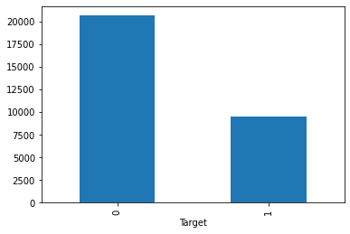

```python
train_labels.groupby('Target').size().plot.bar()
print(train_labels.groupby('Target').size() / train_labels.shape[0])
```

**Detailed Class Info Data¶**

However, we may use the detailed information that been listed in stage_2_detailed_class_info.csv.

We revisit what is inside that file

```python
data_info.head(6)
```

|  | patientId | class |
| --- | --- | --- |
| 0 | 0004cfab-14fd-4e49-80ba-63a80b6bddd6 | No Lung Opacity / Not Normal |
| 1 | 00313ee0-9eaa-42f4-b0ab-c148ed3241cd | No Lung Opacity / Not Normal |
| 2 | 00322d4d-1c29-4943-afc9-b6754be640eb | No Lung Opacity / Not Normal |
| 3 | 003d8fa0-6bf1-40ed-b54c-ac657f8495c5 | Normal |
| 4 | 00436515-870c-4b36-a041-de91049b9ab4 | Lung Opacity |
| 5 | 00436515-870c-4b36-a041-de91049b9ab4 | Lung Opacity |

```
class
Lung Opacity                    0.316108
No Lung Opacity / Not Normal    0.391074
Normal                          0.292818
dtype: float64
```

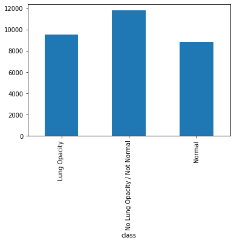

```python
data_info.groupby('class').size().plot.bar()
print(data_info.groupby('class').size() / train_labels.shape[0])
```

As you can see we can add a new column called class to the training data, that will help us build more nuanced models.

Now we got general target called Target which contains only two classes 0 and 1, and detailed target calsses No Lung Opacity / Not Normal, Normal and Lung Opacity

## **Data preparation and further EDA**

```python
train_data = pd.concat([train_labels,data_info['class']], axis = 1)
```

```python
train_data.head(7)
```

|  | patientId | x | y | width | height | Target | class |
| --- | --- | --- | --- | --- | --- | --- | --- |
| 0 | 0004cfab-14fd-4e49-80ba-63a80b6bddd6 | NaN | NaN | NaN | NaN | 0 | No Lung Opacity / Not Normal |
| 1 | 00313ee0-9eaa-42f4-b0ab-c148ed3241cd | NaN | NaN | NaN | NaN | 0 | No Lung Opacity / Not Normal |
| 2 | 00322d4d-1c29-4943-afc9-b6754be640eb | NaN | NaN | NaN | NaN | 0 | No Lung Opacity / Not Normal |
| 3 | 003d8fa0-6bf1-40ed-b54c-ac657f8495c5 | NaN | NaN | NaN | NaN | 0 | Normal |
| 4 | 00436515-870c-4b36-a041-de91049b9ab4 | 264.0 | 152.0 | 213.0 | 379.0 | 1 | Lung Opacity |
| 5 | 00436515-870c-4b36-a041-de91049b9ab4 | 562.0 | 152.0 | 256.0 | 453.0 | 1 | Lung Opacity |
| 6 | 00569f44-917d-4c86-a842-81832af98c30 | NaN | NaN | NaN | NaN | 0 | No Lung Opacity / Not Normal |

```python
unique_train_data = train_data.drop_duplicates(subset= 'patientId')
```

```python
unique_train_data.head(6)
```

|  | patientId | x | y | width | height | Target | class |
| --- | --- | --- | --- | --- | --- | --- | --- |
| 0 | 0004cfab-14fd-4e49-80ba-63a80b6bddd6 | NaN | NaN | NaN | NaN | 0 | No Lung Opacity / Not Normal |
| 1 | 00313ee0-9eaa-42f4-b0ab-c148ed3241cd | NaN | NaN | NaN | NaN | 0 | No Lung Opacity / Not Normal |
| 2 | 00322d4d-1c29-4943-afc9-b6754be640eb | NaN | NaN | NaN | NaN | 0 | No Lung Opacity / Not Normal |
| 3 | 003d8fa0-6bf1-40ed-b54c-ac657f8495c5 | NaN | NaN | NaN | NaN | 0 | Normal |
| 4 | 00436515-870c-4b36-a041-de91049b9ab4 | 264.0 | 152.0 | 213.0 | 379.0 | 1 | Lung Opacity |
| 6 | 00569f44-917d-4c86-a842-81832af98c30 | NaN | NaN | NaN | NaN | 0 | No Lung Opacity / Not Normal |

```
class
Lung Opacity                    0.225304
No Lung Opacity / Not Normal    0.443000
Normal                          0.331697
dtype: float64
```

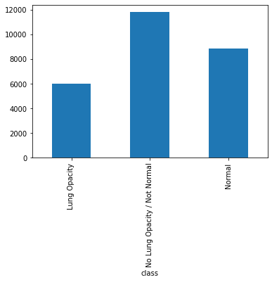

```python
unique_train_data.groupby('class').size().plot.bar()
print(unique_train_data.groupby('class').size() / unique_train_data.shape[0])
```

```
Target
0    0.774696
1    0.225304
dtype: float64
```

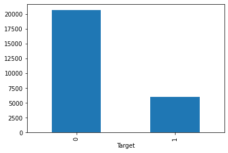

```python
unique_train_data.groupby('Target').size().plot.bar()
print(unique_train_data.groupby('Target').size() / unique_train_data.shape[0])
```

## **Data Visualization**

**Utility functions**

```python
def get_sample(dataframe, img_dir, patientId):
  '''
  helper function used to parse a sample from the data
  args:
  dataframe: pandas dataframe (e.g train, test)
  img_dir: directory to data images (.dcm)
  patientId: unique Id of the patient

  returns:
  gray scale image of the patient, bouding box values, target, patient_class
  '''
  x =[]
  y = []
  h = []
  w = []
  for i,j in zip(dataframe['patientId'],range(len(dataframe))):
    if i == patientId:
      patient = dataframe.iloc[j,:]
      x.append(patient[1])
      y.append(patient[2])
      w.append(patient[3])
      h.append(patient[4])
      target = patient[5]
      p_class = patient[6]

  dcm_data = img_dir+'/%s.dcm' % patientId
  dcm_data = pydicom.read_file(dcm_data)
  img = dcm_data.pixel_array

  return img, x, y, h, w, target, p_class
```

```python
def draw(img, x, y, h, w):
  '''
  helper function used to draw a bounding box/s of the areas of the lung
  args:
  img: grayscale image of the pateint's chest X-ray
  x,y,h,w: bounding box parameters

  returns:
  grayscale images with drawn bounding box if exists
  '''
  fig,ax = plt.subplots(1)
  for x_sub,y_sub,h_sub,w_sub in zip(x, y, h, w):
    rect = patches.Rectangle((x_sub,y_sub),w_sub,h_sub,linewidth=1,edgecolor='r',facecolor='none')
    ax.add_patch(rect)

  pylab.imshow(img, cmap=pylab.cm.gist_gray)
  ax.add_patch(rect)
  plt.show()
```

```
1 Lung Opacity
```

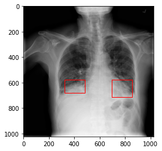

```python
img, x, y, h, w, target, p_class = get_sample(dataframe=train_data,
                                              img_dir='stage_2_train_images',
                                              patientId='00704310-78a8-4b38-8475-49f4573b2dbb')
print(target, p_class)
draw(img,x,y,h,w)
```

```
1 Lung Opacity
```

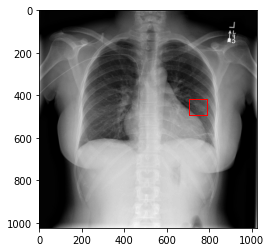

```python
img, x, y, h, w, target, p_class = get_sample(dataframe=train_data,
                                              img_dir='stage_2_train_images',
                                              patientId='0100515c-5204-4f31-98e0-f35e4b00004a')
print(target, p_class)
draw(img,x,y,h,w)
```

```
0 No Lung Opacity / Not Normal
```

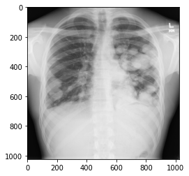

```python
img, x, y, h, w, target, p_class = get_sample(dataframe=train_data,
                                              img_dir='stage_2_train_images',
                                              patientId='00322d4d-1c29-4943-afc9-b6754be640eb')
print(target, p_class)
draw(img,x,y,h,w)
```

```
0 Normal
```

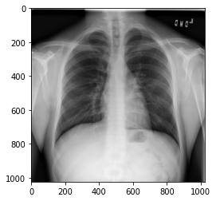

```python
img, x, y, h, w, target, p_class = get_sample(dataframe=train_data,
                                              img_dir='stage_2_train_images',
                                              patientId='003d8fa0-6bf1-40ed-b54c-ac657f8495c5')
print(target, p_class)
draw(img,x,y,h,w)
```

# **MORE FINDINGS FROM EDA DONE SEPARATELY**

### Further details on the data:-

total number of patientId :: 26684 Total number of patients with Non null patientSex :: 26684 Total number of patients with Non null patientAge :: 26684 Number of missing values to be imputed for the first field :: 0 Number of missing values to be imputed for the second field :: 0

### Histogram below using patient age group

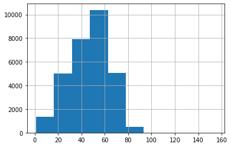

### Below histogram shows outliers with patients age > 90

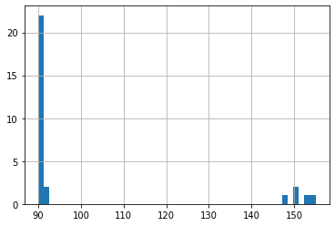

### Below histogram shows division of patient based on their gender.

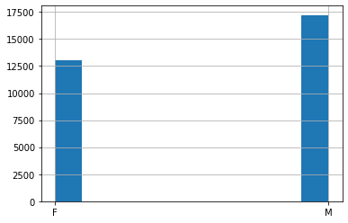

### Given below are data images for patients > 100

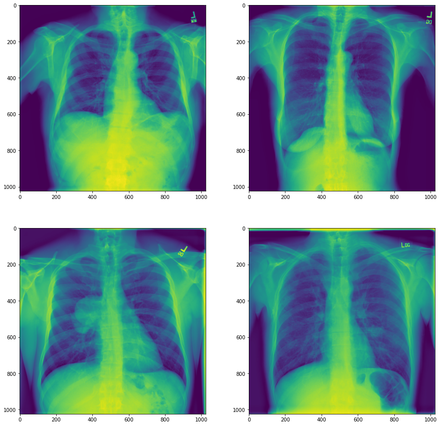

### Given below are data images for patients < 5 year of age

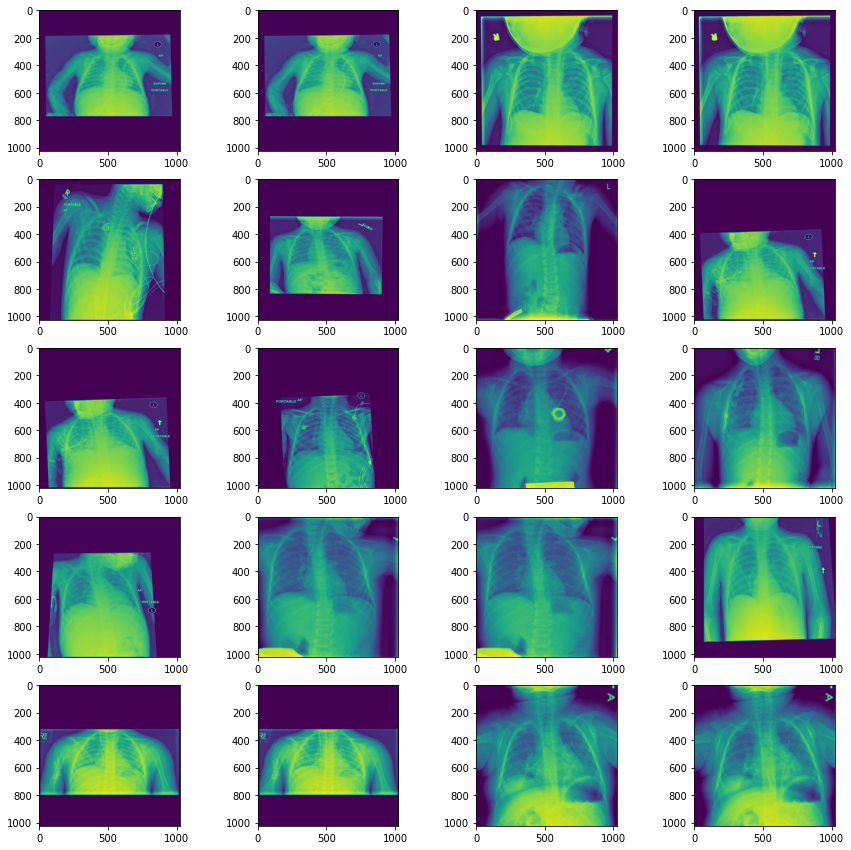

### EDA on pneumonia per age category with classes

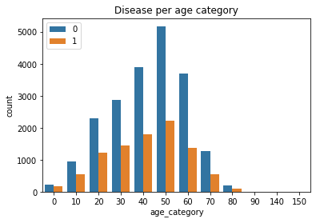

The above output shows distribution slightly skewed to the left

### EDA on disease per gender

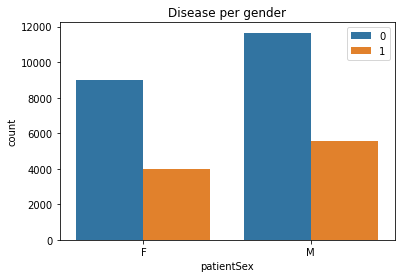

The output shows slightly higher cases of pneumonia in male patients when compared to the female patients

## **Data pre-processing**

Split the train data into train and validation

Note: The following function mainly splits the training images which are 26684 image, and also wrap up a training and validation csv file for the unique patients ID.

```python
def train_split(train_csv, img_dir, split_size = 0.2, base_dir = ''):
  '''
  function used to split the training data into train and validation set
  args:-
    train_csv: Pandas data frame contains all the training information (e.g patientId, x, y, w, etc.)
    img_dir: Path to training image directory
    split_size: How much you want to split the validation set from the training data
    base_dir: Base directory to join it with img_dir

  returns:
    training_info and validation_info: Those two dataframes contain all the information after spliting
  '''

  train_dir = os.path.join(base_dir,'train')
  validation_dir = os.path.join(base_dir,'validation')
  if not os.path.exists(train_dir):
    os.mkdir(train_dir)
  if not os.path.exists(validation_dir):
    os.mkdir(validation_dir)

  training_info = pd.DataFrame(columns=train_csv.columns)
  validation_info = pd.DataFrame(columns=train_csv.columns)

  training_indices = list(range(len(train_csv)))
  random.shuffle(training_indices)
  split_size = (1-split_size)*len(training_indices)

  training_idx = training_indices[:int(split_size)]
  validation_idx = training_indices[int(split_size):]

  for t_patient in training_idx:
    patient = train_csv.iloc[t_patient,:]
    patientId = patient[0]
    src = os.path.join(img_dir, patientId+'.dcm')
    dst = os.path.join(train_dir, patientId+'.dcm')
    shutil.copyfile(src, dst)
    training_info = training_info.append(patient, ignore_index=True)

  for v_patient in validation_idx:
    patient = train_csv.iloc[v_patient,:]
    patientId = patient[0]
    src = os.path.join(img_dir, patientId+'.dcm')
    dst = os.path.join(validation_dir, patientId+'.dcm')
    shutil.copyfile(src, dst)
    validation_info = validation_info.append(patient, ignore_index=True)

  print('total training data:', len(os.listdir(train_dir)))
  print('total validation data:', len(os.listdir(validation_dir)))
  return training_info, validation_info
```

```python
training_info, validation_info = train_split(unique_train_data,'stage_2_train_images',split_size=0.1)
```

```
total training data: 24015
total validation data: 2669
```

```python
print(len(training_info), len(validation_info))
```

```
24015 2669
```

# **Data generator**

The idea behind using a **Keras generator** is to get batches of input and corresponding output on the fly during training process, e.g. reading in 100 images, getting corresponding 100 label vectors and then feeding this set to the gpu for training step.

Every Sequence must implement the **getitem** and the **len** methods. If you want to modify your dataset between epochs you may implement on_epoch_end. The method **getitem** should return a complete batch.

Sequence are a safer way to do multiprocessing. This structure guarantees that the network will only train once on each sample per epoch which is not the case with generators.

```python
class DataGenerator(keras.utils.Sequence):
  def __init__(self,data_csv, img_dir, batch_size=32, dim=(256,256),
               n_classes=2, transform=None, n_channels=1, shuffle=True,
               classes ={'Normal':0,'No Lung Opacity / Not Normal':1,'Lung Opacity': 2}, debug = False):
    '''Initialization
    args:-
      data_csv: data csv contains all the information of the patients
      img_dir: directory that contains the images
      batch_size: value of the batch size
      dim: tuple that contains the dimension of the generated images
      n_channels: value of the number of the channels of the images to be generated
      n_classes: if equal to 2 it will generate based on `Target` column,
                 and if equal to 3 it will generate based on `class` column
      self.classes: dict that map every categorical class to numerical value
      transform: Any list of transformation to be applied on the data (Augmentation)
      shuffle: bolean value if set to True, the data will be shuffled at the start of every epoch
    '''
    self.data_csv = data_csv
    self.patientIds = self.data_csv['patientId']
    self.img_dir = img_dir
    self.batch_size = batch_size
    self.dim = dim
    self.n_channels = n_channels
    self.n_classes = n_classes
    if n_classes == 2:
      self.classes = classes ={'Normal':0,'Lung Opacity': 1}
    else:
      self.classes = classes
    self.shuffle = shuffle
    self.debug = debug
    self.transform = transform
    self.on_epoch_end()

  def __len__(self):
    '''Denotes the number of batches per epoch
        returns:-
          number of batches per epoch'''
    return int(np.floor(len(self.data_csv) / self.batch_size))

  def __getitem__(self,index):
    '''Generate one batch of data
      args:-
        index: index of the batch
      returns:
        imgs and labels when fitting, imgs only when predicting'''
    #Generate indexes of the batch
    indexes = self.indexes[index*self.batch_size:(index+1)*self.batch_size]

    #Find the list of patientIds
    list_IDs_batch = [self.patientIds[k] for k in indexes]

    imgs, labels = self.__data_generation(list_IDs_batch, self.n_classes)

    if self.debug:
      return list_IDs_batch, imgs, labels
    else :
      return imgs, labels

  #maybe the same images
  def on_epoch_end(self):
    '''
    Updates indexes after each epoch
      '''
    self.indexes = np.arange(len(self.data_csv))
    if self.shuffle == True:
      np.random.shuffle(self.indexes)

  def __data_generation(self, list_IDs_batch, n_classes):
    '''
    Generates data containing batch_size samples
    args:-
        list_Ids_batch: lsit of the patientIds of specific batch number
    return:-
        imgs: An array of the patients images with shape (n_samples, *dim, n_channels) == 4D tensor
        labels: An array of encoded labels'''
    imgs = np.empty((self.batch_size, *self.dim, self.n_channels))
    labels = np.empty((self.batch_size), dtype=int)

    for i, ID in enumerate(list_IDs_batch):
      #Store patient image
      imgs[i,] = self.load_img(self.img_dir, ID, self.dim)
      labels[i] = self.get_label(ID, self.n_classes)
    if n_classes ==3:
      labels = keras.utils.to_categorical(labels, num_classes= n_classes) #one hot encoded if # of classes3
    return imgs, labels


  def load_img(self, img_dir, patientId,dim):
    '''
    helper function used to load patient image by `patientID`
    '''
    dcm_data = img_dir+'/%s.dcm' % patientId
    dcm_data = pydicom.read_file(dcm_data)
    img = dcm_data.pixel_array
    img = cv2.resize(img,dim)
    img = img.reshape((dim[0],dim[1],1))
    if not self.transform == None:
      params = self.transform.get_random_transform(img.shape)
      img = self.transform.apply_transform(img,params)
    else:
      img = np.float32(img) / 255.
    return img

  def get_label(self,patientId, n_classes):
    '''
    helper function used to get label specified label of the patient
    based on number of classes it will return the label of the patient
    '''
    full_info = train_data.loc[train_data['patientId'] == patientId].values
    if n_classes == 2:

      return int(full_info[0][-2]) #get the corresponding numerical value (0,1)

    elif n_classes == 3:
      class_label = full_info[:,-1] #get class type (e.g Normal, Lung Opacity)
      class_string = class_label[0]
      return int(self.classes[class_string]) #get the corresponding numerical value (0,1,2)
```

### **We will use data generator function and prepare the batch data for training and validation**

```python
train_generator = DataGenerator(data_csv = training_info, img_dir='train',
                                batch_size=32, dim=(256,256), n_classes=2)

validation_generator = DataGenerator(data_csv = validation_info, img_dir='validation',
                                batch_size=32, dim=(256,256), n_classes=2)
```

### **Data augmentation using image data generator**

```python
transform = ImageDataGenerator(rotation_range=15,
                               rescale = 1/255. ,
                               horizontal_flip=True,
                               zoom_range=[0.5,1.0])
validation_transform = ImageDataGenerator(rescale = 1/255.)

train_generator = DataGenerator(data_csv = training_info, img_dir='train',
                                batch_size=32, dim=(256,256), n_classes=3, transform=transform)

validation_generator = DataGenerator(data_csv = validation_info, img_dir='validation',
                                batch_size=32, dim=(256,256), n_classes=3,transform=validation_transform)
```

```python
print("Number of batches for training set= ", len(train_generator))
print("Number of batches for validation set= ", len(validation_generator))
```

[output not shown]

## **We will build custom CNN in the begining to see how it perform**

```
Model: "model_1"
_________________________________________________________________
Layer (type)                 Output Shape              Param #
=================================================================
input_1 (InputLayer)         (None, 256, 256, 1)       0
_________________________________________________________________
conv2d_1 (Conv2D)            (None, 253, 253, 32)      544
_________________________________________________________________
max_pooling2d_1 (MaxPooling2 (None, 126, 126, 32)      0
_________________________________________________________________
conv2d_2 (Conv2D)            (None, 124, 124, 64)      18496
_________________________________________________________________
max_pooling2d_2 (MaxPooling2 (None, 62, 62, 64)        0
_________________________________________________________________
conv2d_3 (Conv2D)            (None, 60, 60, 128)       73856
_________________________________________________________________
max_pooling2d_3 (MaxPooling2 (None, 30, 30, 128)       0
_________________________________________________________________
conv2d_4 (Conv2D)            (None, 29, 29, 128)       65664
_________________________________________________________________
max_pooling2d_4 (MaxPooling2 (None, 14, 14, 128)       0
_________________________________________________________________
average_pooling2d_1 (Average (None, 7, 7, 128)         0
_________________________________________________________________
flatten_1 (Flatten)          (None, 6272)              0
_________________________________________________________________
dense_1 (Dense)              (None, 2400)              15055200
_________________________________________________________________
dropout_1 (Dropout)          (None, 2400)              0
_________________________________________________________________
dense_2 (Dense)              (None, 1024)              2458624
_________________________________________________________________
dense_3 (Dense)              (None, 3)                 3075
=================================================================
Total params: 17,675,459
Trainable params: 17,675,459
Non-trainable params: 0
_________________________________________________________________
None
```

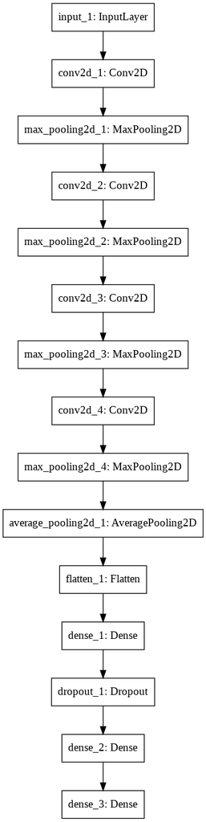

```python
input_img = Input(shape=(256,256,1))
conv1 = Convolution2D(32, kernel_size=4, activation='relu')(input_img)
pool1 = MaxPooling2D(pool_size=(2, 2))(conv1)

conv2 = Convolution2D(64, kernel_size=3, activation='relu')(pool1)
pool2 = MaxPooling2D(pool_size=(2, 2))(conv2)

conv3 = Convolution2D(128, kernel_size=3, activation='relu')(pool2)
pool3 = MaxPooling2D(pool_size=(2, 2))(conv3)

conv4 = Convolution2D(128, kernel_size=2, activation='relu')(pool3)
pool4 = MaxPooling2D(pool_size=(2, 2))(conv4)

pool_GAP = AveragePooling2D()(pool4)
flat = Flatten()(pool_GAP)

hidden1 = Dense(2400, activation='relu')(flat)
drop1 = Dropout(0.25)(hidden1)

hidden2 = Dense(1024, activation='relu')(drop1)
#drop2 = Dropout(0.25)(hidden2)

output =  Dense(3, activation='softmax')(hidden2)

model = Model(inputs=input_img, outputs=output)
# summarize layers
print(model.summary())
# plot graph
plot_model(model, to_file='convolutional_neural_network.png')
```

```python
# Train model on dataset
model.compile(loss='categorical_crossentropy',
              optimizer=optimizers.Adam(),
              metrics=['acc'])
history = model.fit_generator(generator=train_generator,
                  validation_data=validation_generator,use_multiprocessing =True, epochs= 25)
```

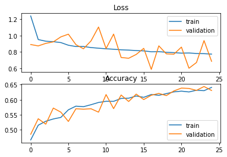

```python
# plot loss during training
plt.subplot(211)
plt.title('Loss')
plt.plot(history.history['loss'], label='train')
plt.plot(history.history['val_loss'], label='validation')
plt.legend()
# plot accuracy during training
plt.subplot(212)
plt.title('Accuracy')
plt.plot(history.history['acc'], label='train')
plt.plot(history.history['val_acc'], label='validation')
plt.legend()
plt.show()
```

# **The next stage is to start regularizing and tuning the hyperparameters**

```
Model: "model_2"
_________________________________________________________________
Layer (type)                 Output Shape              Param #
=================================================================
input_2 (InputLayer)         (None, 224, 224, 1)       0
_________________________________________________________________
conv2d_5 (Conv2D)            (None, 222, 222, 32)      320
_________________________________________________________________
conv2d_6 (Conv2D)            (None, 220, 220, 32)      9248
_________________________________________________________________
max_pooling2d_5 (MaxPooling2 (None, 110, 110, 32)      0
_________________________________________________________________
conv2d_7 (Conv2D)            (None, 108, 108, 64)      18496
_________________________________________________________________
conv2d_8 (Conv2D)            (None, 106, 106, 64)      36928
_________________________________________________________________
max_pooling2d_6 (MaxPooling2 (None, 53, 53, 64)        0
_________________________________________________________________
conv2d_9 (Conv2D)            (None, 51, 51, 128)       73856
_________________________________________________________________
conv2d_10 (Conv2D)           (None, 49, 49, 128)       147584
_________________________________________________________________
max_pooling2d_7 (MaxPooling2 (None, 24, 24, 128)       0
_________________________________________________________________
conv2d_11 (Conv2D)           (None, 22, 22, 128)       147584
_________________________________________________________________
conv2d_12 (Conv2D)           (None, 20, 20, 128)       147584
_________________________________________________________________
max_pooling2d_8 (MaxPooling2 (None, 10, 10, 128)       0
_________________________________________________________________
flatten_2 (Flatten)          (None, 12800)             0
_________________________________________________________________
dense_4 (Dense)              (None, 1024)              13108224
_________________________________________________________________
dropout_2 (Dropout)          (None, 1024)              0
_________________________________________________________________
dense_5 (Dense)              (None, 1)                 1025
=================================================================
Total params: 13,690,849
Trainable params: 13,690,849
Non-trainable params: 0
_________________________________________________________________
None
```

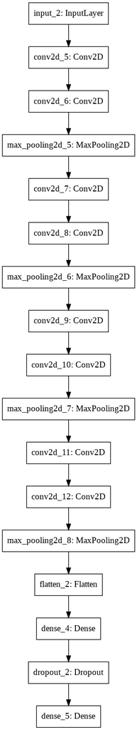

```python
input_img = Input(shape=(224,224,1))
conv1 = Convolution2D(32, kernel_size=3, activation='relu')(input_img)
conv1_1 = Convolution2D(32, kernel_size=3, activation='relu')(conv1)
pool1 = MaxPooling2D(pool_size=(2, 2))(conv1_1)

conv2 = Convolution2D(64, kernel_size=3, activation='relu')(pool1)
conv2_2 = Convolution2D(64, kernel_size=3, activation='relu')(conv2)
pool2 = MaxPooling2D(pool_size=(2, 2))(conv2_2)

conv3 = Convolution2D(128, kernel_size=3, activation='relu')(pool2)
conv3_3 = Convolution2D(128, kernel_size=3, activation='relu')(conv3)
pool3 = MaxPooling2D(pool_size=(2, 2))(conv3_3)

conv4 = Convolution2D(128, kernel_size=3, activation='relu')(pool3)
conv4_4 = Convolution2D(128, kernel_size=3, activation='relu')(conv4)
pool4 = MaxPooling2D(pool_size=(2, 2))(conv4_4)

flat = Flatten()(pool4)

hidden1 = Dense(1024, activation='relu')(flat)
drop1 = Dropout(0.5)(hidden1)

output =  Dense(1, activation='sigmoid')(drop1)

model2 = Model(inputs=input_img, outputs=output)
# summarize layers
print(model2.summary())
# plot graph
plot_model(model2, to_file='convolutional_neural_network.png')
```

```python
#Data Generator
transform = ImageDataGenerator(rotation_range=10,
                               rescale = 1/255. ,
                               horizontal_flip=True,
                               zoom_range=[0.5,1.0])

validation_transform = ImageDataGenerator(rescale = 1/255.)

train_generator = DataGenerator(data_csv = training_info, img_dir='train',
                                batch_size=64, dim=(224,224), n_classes=2, transform=None)

validation_generator = DataGenerator(data_csv = validation_info, img_dir='validation',
                                batch_size=64, dim=(224,224), n_classes=2,transform=None)
# Train model on dataset
model2.compile(loss='binary_crossentropy',
              optimizer=optimizers.RMSprop(0.001),
              metrics=['acc'])
history2 = model2.fit_generator(generator=train_generator,
                  validation_data=validation_generator, epochs= 25)

model2.save("modeltunned.h5")
# plot loss during training
plt.subplot(211)
plt.title('Loss')
plt.plot(history2.history['loss'], label='train')
plt.plot(history2.history['val_loss'], label='validation')
plt.legend()
# plot accuracy during training
plt.subplot(212)
plt.title('Accuracy')
plt.plot(history2.history['acc'], label='train')
plt.plot(history2.history['val_acc'], label='validation')
plt.legend()
plt.show()
```

[output not shown]

## **Let us train on Inceptionv3 architecture without transfer learning**

```python
input_img = Input(shape=(224,224,1))
input_img_rgb = Concatenate()([input_img, input_img, input_img]) #Convert grayscale img to shape RGB for the model
```

```python
import keras
from keras.applications.inception_v3 import InceptionV3
from keras.preprocessing.image import ImageDataGenerator
from keras.callbacks import ModelCheckpoint,EarlyStopping,ReduceLROnPlateau,Callback
```

```python
def get_model():
  base_model = InceptionV3(input_shape=(224,224,3),weights=None,include_top=False,input_tensor= input_img_rgb)
  x = base_model.output
  x = keras.layers.GlobalAveragePooling2D()(x)
  x = keras.layers.Dense(1024, activation='relu')(x)
  x = keras.layers.BatchNormalization()(x)
  predictions = keras.layers.Dense(1, activation='sigmoid')(x)
  model3 = keras.models.Model(inputs=base_model.inputs, outputs=predictions)

  for layer in base_model.layers:
    layer.trainable = False

  model3.summary()
  return model3
```

```python
model3 = get_model()
```

```
Model: "model_3"
__________________________________________________________________________________________________
Layer (type)                    Output Shape         Param #     Connected to
==================================================================================================
input_3 (InputLayer)            (None, 224, 224, 1)  0
__________________________________________________________________________________________________
concatenate_1 (Concatenate)     (None, 224, 224, 3)  0           input_3[0][0]
                                                                 input_3[0][0]
                                                                 input_3[0][0]
__________________________________________________________________________________________________
conv2d_13 (Conv2D)              (None, 111, 111, 32) 864         concatenate_1[0][0]
__________________________________________________________________________________________________
batch_normalization_1 (BatchNor (None, 111, 111, 32) 96          conv2d_13[0][0]
__________________________________________________________________________________________________
activation_1 (Activation)       (None, 111, 111, 32) 0           batch_normalization_1[0][0]
__________________________________________________________________________________________________
conv2d_14 (Conv2D)              (None, 109, 109, 32) 9216        activation_1[0][0]
__________________________________________________________________________________________________
batch_normalization_2 (BatchNor (None, 109, 109, 32) 96          conv2d_14[0][0]
__________________________________________________________________________________________________
activation_2 (Activation)       (None, 109, 109, 32) 0           batch_normalization_2[0][0]
__________________________________________________________________________________________________
conv2d_15 (Conv2D)              (None, 109, 109, 64) 18432       activation_2[0][0]
__________________________________________________________________________________________________
batch_normalization_3 (BatchNor (None, 109, 109, 64) 192         conv2d_15[0][0]
__________________________________________________________________________________________________
activation_3 (Activation)       (None, 109, 109, 64) 0           batch_normalization_3[0][0]
__________________________________________________________________________________________________
max_pooling2d_9 (MaxPooling2D)  (None, 54, 54, 64)   0           activation_3[0][0]
__________________________________________________________________________________________________
conv2d_16 (Conv2D)              (None, 54, 54, 80)   5120        max_pooling2d_9[0][0]
__________________________________________________________________________________________________
batch_normalization_4 (BatchNor (None, 54, 54, 80)   240         conv2d_16[0][0]
__________________________________________________________________________________________________
activation_4 (Activation)       (None, 54, 54, 80)   0           batch_normalization_4[0][0]
__________________________________________________________________________________________________
conv2d_17 (Conv2D)              (None, 52, 52, 192)  138240      activation_4[0][0]
__________________________________________________________________________________________________
batch_normalization_5 (BatchNor (None, 52, 52, 192)  576         conv2d_17[0][0]
__________________________________________________________________________________________________
```

[output cut: 622 more lines]

```
                                                                 concatenate_3[0][0]
                                                                 activation_94[0][0]
__________________________________________________________________________________________________
global_average_pooling2d_1 (Glo (None, 2048)         0           mixed10[0][0]
__________________________________________________________________________________________________
dense_6 (Dense)                 (None, 1024)         2098176     global_average_pooling2d_1[0][0]
__________________________________________________________________________________________________
batch_normalization_95 (BatchNo (None, 1024)         4096        dense_6[0][0]
__________________________________________________________________________________________________
dense_7 (Dense)                 (None, 1)            1025        batch_normalization_95[0][0]
==================================================================================================
Total params: 23,906,081
Trainable params: 2,101,249
Non-trainable params: 21,804,832
__________________________________________________________________________________________________
```

```python
from keras.optimizers import Adam,rmsprop
optimizer=Adam()
# Train model on dataset
model3.compile(loss='binary_crossentropy',
              optimizer=optimizers.Adam(),
              metrics=['acc'])


checkpointer = ModelCheckpoint(filepath='/content/drive/My Drive/projectwork/data/inception.hdf5', monitor='val_loss',mode='min', verbose=1,save_weights_only=True, save_best_only=True)

stop = EarlyStopping(
    monitor='val_loss',
    patience=5,
    verbose=1,
    restore_best_weights=True)

reduce_lr = ReduceLROnPlateau(
    monitor='val_loss',
    patience=5,
    cooldown=2,
    min_lr=10e-10)
```

```python
history3 = model3.fit_generator(generator=train_generator,

                  validation_data=validation_generator,use_multiprocessing =True, epochs= 25, steps_per_epoch= len(train_generator)+10,callbacks=[checkpointer,reduce_lr, stop])
```

```
Epoch 00001: val_loss improved from inf to 0.61549, saving model to /content/drive/My Drive/projectwork/data/inception.hdf5

Epoch 00002: val_loss improved from 0.61549 to 0.52336, saving model to /content/drive/My Drive/projectwork/data/inception.hdf5

Epoch 00003: val_loss did not improve from 0.52336

Epoch 00004: val_loss did not improve from 0.52336

Epoch 00005: val_loss improved from 0.52336 to 0.50461, saving model to /content/drive/My Drive/projectwork/data/inception.hdf5

Epoch 00006: val_loss did not improve from 0.50461

Epoch 00007: val_loss improved from 0.50461 to 0.50206, saving model to /content/drive/My Drive/projectwork/data/inception.hdf5

Epoch 00008: val_loss improved from 0.50206 to 0.47260, saving model to /content/drive/My Drive/projectwork/data/inception.hdf5

Epoch 00009: val_loss did not improve from 0.47260

Epoch 00010: val_loss did not improve from 0.47260

Epoch 00011: val_loss improved from 0.47260 to 0.40707, saving model to /content/drive/My Drive/projectwork/data/inception.hdf5

Epoch 00012: val_loss did not improve from 0.40707

Epoch 00013: val_loss did not improve from 0.40707

Epoch 00014: val_loss did not improve from 0.40707

Epoch 00015: val_loss did not improve from 0.40707

Epoch 00016: val_loss did not improve from 0.40707
Restoring model weights from the end of the best epoch
Epoch 00016: early stopping
```

```python
model3.save("modelinception.h5")
# plot loss during training
plt.subplot(211)
plt.title('Loss')
plt.plot(history2.history['loss'], label='train')
plt.plot(history2.history['val_loss'], label='validation')
plt.legend()
# plot accuracy during training
plt.subplot(212)
plt.title('Accuracy')
plt.plot(history2.history['acc'], label='train')
plt.plot(history2.history['val_acc'], label='validation')
plt.legend()
plt.show()
```

[output not shown]

## **Let us train on Vgg16 architecture without using any transfer learning**

```python
input_img = Input(shape=(224,224,1))
input_img_rgb = Concatenate()([input_img, input_img, input_img]) #Convert grayscale img to shape RGB for the model
```

```python
from keras.models import Model
```

```python
from sklearn.utils import class_weight
from keras.models import load_model
from keras.applications import vgg16
from keras.layers import MaxPooling2D, Dropout, Flatten, BatchNormalization, Dense
from keras import regularizers
from keras.applications.densenet import  preprocess_input
```

```python
def get_model():
  base = vgg16.VGG16(weights=None, include_top=False, input_shape=(224,224,3),input_tensor= input_img_rgb)
  x = base.output
  x = MaxPooling2D()(x)
  x = Flatten()(x)
  x = Dense(256, activation='relu', activity_regularizer=regularizers.l2(10e-8))(x)
  x = Dropout(.25)(x)
  x = Dense(512, activation = 'relu')(x)
  x = Dropout(.25)(x)
  pred = Dense(1, activation='sigmoid')(x)

  model4=Model(inputs=base.input, outputs=pred)

  for layer in base.layers:
    layer.trainable = False

  model4.summary()
  return model4
```

```python
model4 = get_model()
```

```
Model: "model_4"
__________________________________________________________________________________________________
Layer (type)                    Output Shape         Param #     Connected to
==================================================================================================
input_4 (InputLayer)            (None, 224, 224, 1)  0
__________________________________________________________________________________________________
concatenate_4 (Concatenate)     (None, 224, 224, 3)  0           input_4[0][0]
                                                                 input_4[0][0]
                                                                 input_4[0][0]
__________________________________________________________________________________________________
block1_conv1 (Conv2D)           (None, 224, 224, 64) 1792        concatenate_4[0][0]
__________________________________________________________________________________________________
block1_conv2 (Conv2D)           (None, 224, 224, 64) 36928       block1_conv1[0][0]
__________________________________________________________________________________________________
block1_pool (MaxPooling2D)      (None, 112, 112, 64) 0           block1_conv2[0][0]
__________________________________________________________________________________________________
block2_conv1 (Conv2D)           (None, 112, 112, 128 73856       block1_pool[0][0]
__________________________________________________________________________________________________
block2_conv2 (Conv2D)           (None, 112, 112, 128 147584      block2_conv1[0][0]
__________________________________________________________________________________________________
block2_pool (MaxPooling2D)      (None, 56, 56, 128)  0           block2_conv2[0][0]
__________________________________________________________________________________________________
block3_conv1 (Conv2D)           (None, 56, 56, 256)  295168      block2_pool[0][0]
__________________________________________________________________________________________________
block3_conv2 (Conv2D)           (None, 56, 56, 256)  590080      block3_conv1[0][0]
__________________________________________________________________________________________________
block3_conv3 (Conv2D)           (None, 56, 56, 256)  590080      block3_conv2[0][0]
__________________________________________________________________________________________________
block3_pool (MaxPooling2D)      (None, 28, 28, 256)  0           block3_conv3[0][0]
__________________________________________________________________________________________________
block4_conv1 (Conv2D)           (None, 28, 28, 512)  1180160     block3_pool[0][0]
__________________________________________________________________________________________________
block4_conv2 (Conv2D)           (None, 28, 28, 512)  2359808     block4_conv1[0][0]
__________________________________________________________________________________________________
block4_conv3 (Conv2D)           (None, 28, 28, 512)  2359808     block4_conv2[0][0]
__________________________________________________________________________________________________
block4_pool (MaxPooling2D)      (None, 14, 14, 512)  0           block4_conv3[0][0]
__________________________________________________________________________________________________
block5_conv1 (Conv2D)           (None, 14, 14, 512)  2359808     block4_pool[0][0]
__________________________________________________________________________________________________
```

[output cut: 9 more lines]

```
__________________________________________________________________________________________________
dense_8 (Dense)                 (None, 256)          1179904     flatten_3[0][0]
__________________________________________________________________________________________________
dropout_3 (Dropout)             (None, 256)          0           dense_8[0][0]
__________________________________________________________________________________________________
dense_9 (Dense)                 (None, 512)          131584      dropout_3[0][0]
__________________________________________________________________________________________________
dropout_4 (Dropout)             (None, 512)          0           dense_9[0][0]
__________________________________________________________________________________________________
dense_10 (Dense)                (None, 1)            513         dropout_4[0][0]
==================================================================================================
Total params: 16,026,689
Trainable params: 1,312,001
Non-trainable params: 14,714,688
__________________________________________________________________________________________________
```

```python
from keras.optimizers import Adam,rmsprop
optimizer=Adam()
# Train model on dataset
model4.compile(loss='binary_crossentropy',
              optimizer=optimizers.Adam(),
              metrics=['acc'])


checkpointer = ModelCheckpoint(filepath='/content/drive/My Drive/projectwork/data/vgg16w.hdf5', monitor='val_loss',mode='min', verbose=1,save_weights_only=True, save_best_only=True)

stop = EarlyStopping(
    monitor='val_loss',
    patience=5,
    verbose=1,
    restore_best_weights=True)

reduce_lr = ReduceLROnPlateau(
    monitor='val_loss',
    patience=5,
    cooldown=2,
    min_lr=10e-10)
```

```python
history4 = model4.fit_generator(generator=train_generator,

                  validation_data=validation_generator,use_multiprocessing =True, epochs= 25, steps_per_epoch= len(train_generator)+10,callbacks=[checkpointer,reduce_lr, stop])
```

```
Epoch 00001: val_loss improved from inf to 0.45688, saving model to /content/drive/My Drive/projectwork/data/vgg16w.hdf5

Epoch 00002: val_loss improved from 0.45688 to 0.44779, saving model to /content/drive/My Drive/projectwork/data/vgg16w.hdf5

Epoch 00003: val_loss did not improve from 0.44779

Epoch 00004: val_loss improved from 0.44779 to 0.36481, saving model to /content/drive/My Drive/projectwork/data/vgg16w.hdf5

Epoch 00005: val_loss did not improve from 0.36481

Epoch 00006: val_loss did not improve from 0.36481

Epoch 00007: val_loss did not improve from 0.36481

Epoch 00008: val_loss did not improve from 0.36481

Epoch 00009: val_loss improved from 0.36481 to 0.33407, saving model to /content/drive/My Drive/projectwork/data/vgg16w.hdf5

Epoch 00010: val_loss did not improve from 0.33407

Epoch 00011: val_loss did not improve from 0.33407

Epoch 00012: val_loss did not improve from 0.33407

Epoch 00013: val_loss did not improve from 0.33407

Epoch 00014: val_loss did not improve from 0.33407
Restoring model weights from the end of the best epoch
Epoch 00014: early stopping
```

```python
model4.save("modelvgg.h5")
# plot loss during training
plt.subplot(211)
plt.title('Loss')
plt.plot(history2.history['loss'], label='train')
plt.plot(history2.history['val_loss'], label='validation')
plt.legend()
# plot accuracy during training
plt.subplot(212)
plt.title('Accuracy')
plt.plot(history2.history['acc'], label='train')
plt.plot(history2.history['val_acc'], label='validation')
plt.legend()
plt.show()
```

[output not shown]